# Project: Train a Quadcopter How to Fly

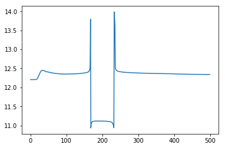

```python
# Tried batch size of 128
# [DDPG paper] Changed tau default of 0.01 to `tau = 0.001`
# [DDPG paper] lr 0.0001 actor, 0.001 critic
plt.plot(rewards)
_ = plt.ylim()
```

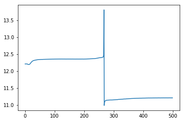

```python
# Back to default batch size of 64
# [DDPG paper] Changed tau default of 0.01 to `tau = 0.001`
# [DDPG paper] lr 0.0001 actor, 0.001 critic
plt.plot(rewards)
_ = plt.ylim()
```

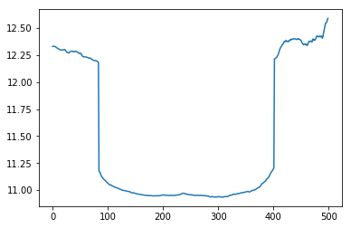

```python
# Tried batch normalization
# Tried batch size of 32
# [DDPG paper] Changed tau default of 0.01 to `tau = 0.001`
# [DDPG paper] lr 0.0001 actor, 0.001 critic
plt.plot(rewards)
_ = plt.ylim()
```

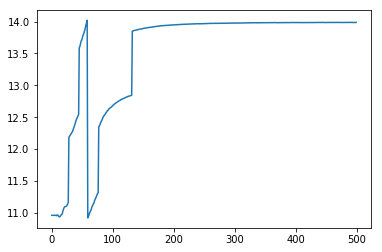

```python
# Tried batch normalization
plt.plot(rewards)
_ = plt.ylim()
```

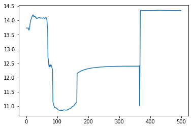

```python
# Added L2 regularization of 0.001 to the actor and critic final output layers
# Tried batch normalization
plt.plot(rewards)
_ = plt.ylim()
```

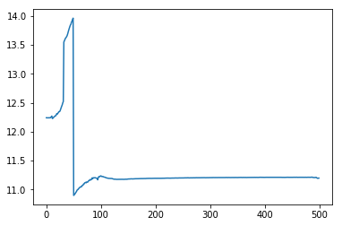

```python
# Added L2 regularization of 0.01 to the actor and critic final output layers
# Tried batch normalization
plt.plot(rewards)
_ = plt.ylim()
```

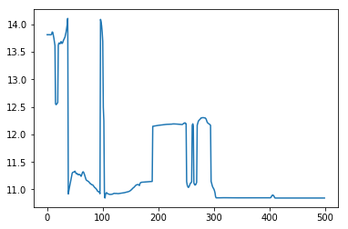

```python
# [DDPG paper] Added L2 regularization of 0.01 to the critic final output layer
# Tried batch normalization
plt.plot(rewards)
_ = plt.ylim()
```

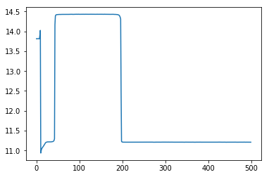

```python
# NN default
plt.plot(rewards)
_ = plt.ylim()
```

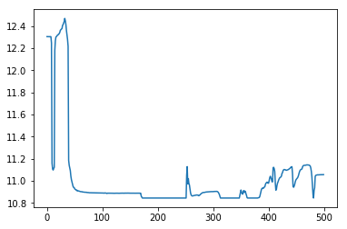

```python
# Tried batch normalization
plt.plot(rewards)
_ = plt.ylim()
```

### Takeoff + Hover Task

- The plots show rewards on the y-axis versus number of episodes on the x-axis.
- Decided not to experiment changing the DDPG code with this task because out-of-the-box, the takeoff task looked more promising to work with.

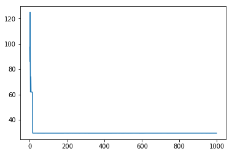

```python
# 1000 episodes, rotors at same speed
plt.plot(rewards)
_ = plt.ylim()
```

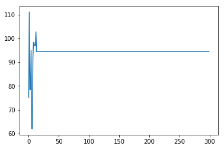

```python
# 300 episodes, rotors at same speed
plt.plot(rewards)
_ = plt.ylim()
```

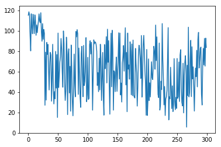

```python
# 300 episodes, rotors at different speeds
plt.plot(rewards)
_ = plt.ylim()
```

## Reflections

**Question 1**: Describe the task that you specified in `task.py`. How did you design the reward function?

**Answer**: I specified the takeoff plus reach a target pose task in `task.py`, as made apparent by the `get_reward` and `step` methods. While the `__init__` method doesn't specify the `init_pose` and `target_pos`, in the code to train the agent above (in cell 383), I set the following initial settings outside of the `task.py` file:

```
init_pose = np.array([0., 0., 0., 0., 0., 0.])
target_pos = np.array([0., 0., 10.])
init_velocities = np.array([0., 0., 30.])
init_angle_velocities = np.array([0., 0., 30.])
```

Therefore, the task is to take off from the ground and reach 10 meters in vertical height (comparing z-axis only, ignoring x and y). Once 10 meters or more in height has been achieved, the task is considered complete and the episode ends. Note that I needed to set the initial and angular velocities of the quadcopter to 30 or else the simulation would consistently crash the copter into the ground due to the force of gravity, preventing learning from ever taking place if I used values below 30.

The reward function in `get_reward` is simply the normalized z-axis velocity (between values -1 to 1) of the quadcopter. So the reward is positive if the copter travels upwards and negative if the copter travels downwards. The reward is greater the faster the copter travels upwards and smaller the faster the copter travels downwards. However, one thing to note is that a velocity limit of 50 has been set, meaning that the copter will achieve the maximum reward of +1 traveling upwards if it reaches a velocity of 50 or greater, and it will be penalized the minimum reward of -1 traveling downwards if it reaches a velocity of -50 or lower.

Apart from the normalized velocity as the reward, an additional reward of +1 is given if the copter has reached (or passed) the vertical height target. And the `step` method has been modified to terminate the episode once the target is reached. These settings allow the agent to have more episode iterations and recognize when it has succeeded.

**Question 2**: Discuss your agent briefly, using the following questions as a guide:

- What learning algorithm(s) did you try? What worked best for you?
- What was your final choice of hyperparameters (such as $\alpha$, $\gamma$, $\epsilon$, etc.)?
- What neural network architecture did you use (if any)? Specify layers, sizes, activation functions, etc.

**Answer**: The SimpleAgent in `agent.py` is simply the PolicySearch_Agent but with a modified `act` method. While the simple linear policy is still applied beforehand, the rotors are then set to the same speed by taking the mean across all 4 rotor speeds. This mean is the same speed that each of the rotors are set to before the action is returned. Setting all 4 rotors to the same speed per action restricts the quadcopter from moving in any other direction besides along the z-axis (up or down). This also prevents twisting and turning.

- The only learning algorithm I attempted was DDPG, using the Keras-based code provided by Udacity in the project classroom. I first got the agent to learn using the SimpleAgent, but then I tried the DDPG agent. Despite tuning some hyperparameters and adding batch normalization and L2 regularization, I don't believe that the DDPG agent learned any better or learned consistently over multiple trials, compared to the SimpleAgent. Thus, the SimpleAgent with its random policy search, worked best for me.
- I do not have a final choice of hyperparameters for the DDPG agent, since nothing I tried worked better than the SimpleAgent. Some changes I made that I thought influenced the agent to learn better was to add batch normalization (you'll see this commented out in the DDPG actor and critic code), and to change tau to a smaller value of 0.001 (from the default of 0.01) and the learning rate in the actor network Adam optimizer to 0.0001 (from the default of 0.001). But none of these really produced any decent plots, such as the plots in cells 384 (before episode 770 or so) and 382.
- For the DDPG agent only, the neural network architecture I attempted to use was the DDPG code provided by Udacity in the classroom. Apart from that, I tried setting all the hidden layers (in both the actor and critic networks) to 32 units or all of them to 64 units, but that didn't seem to help the agent learn any better. And apart from the Udacity code, I tried adding batch normalization and L2 regularization, but those did not help as well. In the end, I deem that the SimpleAgent, for which I did not use a neural network architecture, learned better.

**Question 3**: Using the episode rewards plot, discuss how the agent learned over time.

- Was it an easy task to learn or hard?
- Was there a gradual learning curve, or an aha moment?
- How good was the final performance of the agent? (e.g. mean rewards over the last 10 episodes)

**Answer**:

- Given the constraint to only move up and down and the simple normalized velocity reward function with a terminal reward for reaching the target pose, I believe that the task was easy for the quadcopter to learn. The rewards plots in cells 384 (before episode 770 or so) and 382 further emphasize this -- that learning the task was easy -- by showing an increase in rewards as the number of episodes increases, from episode 0 to 770 or so.
- In plot 384, the learning curve was gradual for about the first 600 episodes and then increased steeply then gradually again until about 770 episodes. In plot 382, the learning curve was gradual for the most part but increased steeply from about episode 45 to 50 or so.
- In plot 384, the final performance of the agent (cutting off the odd behavior past 770) was very good, still steadily increasing, even if the amount of rewards wasn't all that great (only about 0.25 reward points or less). In plot 382, the final performance of the agent was about 0.025 of accumulated rewards in the past 10 episodes; however small, it was still an increase as opposed to a plateau.

**Question 4**: Briefly summarize your experience working on this project. You can use the following prompts for ideas.

- What was the hardest part of the project? (e.g. getting started, plotting, specifying the task, etc.)
- Did you find anything interesting in how the quadcopter or your agent behaved?

**Answer**:

- Getting started was the hardest part of the project; I attempted to start without going through any of the labs, having just watched all of the RL lesson videos. But after glancing at the code, I thought I could better understand how to tackle the project by going through the labs and reviewing my notes. I took another entire week on this and, despite trying to tackle the Dynamic Programming lesson's lab notebook on my own, ended up just running the solutions for the rest of the labs since I was running out of time before this project was due. In the end, what helped me the most was understanding how reinforcement learning solutions are coded via OpenAI Gym (similar to the project's setup) and reading the trials and tribulations that other students went through in the `#ml-reinforcement` Slack channel. The main idea that helped was to simplify the problem as much as I could so that the agent would learn, simply by changing the agent action, task, and reward function, before tackling anything more advanced such as DDPG. Moreover, I truly wish Udacity had provided more resources and lessons on DDPG and implementation labs with DDPG in the continuous learning sections, but I had to try and learn DDPG only from the code provided in the project classroom and a few other articles I read. I still don't understand how to justifiably modify the DDPG code and neural network architectures to make the agent learn better.
- I only found two parts interesting in how the quadcopter behaved for the takeoff + reach a target pose task:
  - In the rewards plot for cell 384, I don't understand why the rewards past episode 770 or so are so different from the rest of the plot (going up and down, up and down, from 11.0 reward points to about 14.3).
  - In the NN default plots 391 and 430, the learning plateaus after around episodes 300 and 200, respectively.
- My ideas to further improve the project if I had more time are as follows:
  - Improve the takeoff + hover task to check for done after hovering has succeeded.
  - Get the agent to learn successfully for each task (including landing), regardless of the x, y, and z initial and target positions. This means that the 4 rotors could move at different speeds.
  - Get the agent to learn successfully for a combination of tasks (such as takeoff + hover + target position not on the ground + landing).
  - Attempt a DQN architecture with discretized state and action spaces.
  - Get DDPG to learn better on one or more tasks and try out more architecture changes.